# An Introduction to Supervised Learning (Part II)

Ryan Miller

## Supervised Learning

- Last time we introduced a framework for supervised learning that centered around estimating $f$:
  $$Y = f(\mathbf{X}) + \epsilon$$
- Here $f$ is a fixed but unknown function of the data, and $\epsilon$ is a random error term
  - $f$ describes the systematic relationship between the features in $\mathbf{X}$ and $Y$

## Linear Regression

- We then discussed **linear regression** models, a type of **parametric** model where the features in $\mathbf{X}$ each make an additive linear contribution to the predictions generated by $f$:
  $$f(\mathbf{X}) = \beta_0 + \beta_1 X_{1} + \beta_2X_2 + \ldots + \beta_pX_p + \epsilon$$
- This model needed to be **trained**, meaning the coefficients ($\beta_j$’s) needed to be estimated from the data
  - Estimation could be done via **ordinary least squares** or the **LASSO**

## Exploratory Data Analysis and Linear Regression

- Ozone ($O_3$) is pollutant that can damage the lungs, it tends to concentrate in urban areas and is a major public health hazard
- When ozone concentrations are high it is advised that high-risk populations remain indoors, but are high-ozone days predictable?

| Ozone | Solar | Wind | Temp | Day |
| --- | --- | --- | --- | --- |
| 41 | 190 | 7.4 | 67 | 121 |
| 36 | 118 | 8.0 | 72 | 122 |
| 12 | 149 | 12.6 | 74 | 123 |
| 18 | 313 | 11.5 | 62 | 124 |
| 23 | 299 | 8.6 | 65 | 127 |
| 19 | 99 | 13.8 | 59 | 128 |
| 8 | 19 | 20.1 | 61 | 129 |
| 16 | 256 | 9.7 | 69 | 132 |
| 11 | 290 | 9.2 | 66 | 133 |
| 14 | 274 | 10.9 | 68 | 134 |
| 18 | 65 | 13.2 | 58 | 135 |
| 14 | 334 | 11.5 | 64 | 136 |
| 34 | 307 | 12.0 | 66 | 137 |
| 6 | 78 | 18.4 | 57 | 138 |
| 30 | 322 | 11.5 | 68 | 139 |
| 11 | 44 | 9.7 | 62 | 140 |
| 1 | 8 | 9.7 | 59 | 141 |
| 11 | 320 | 16.6 | 73 | 142 |
| 4 | 25 | 9.7 | 61 | 143 |
| 32 | 92 | 12.0 | 61 | 144 |
| 23 | 13 | 12.0 | 67 | 148 |
| 45 | 252 | 14.9 | 81 | 149 |
| 115 | 223 | 5.7 | 79 | 150 |
| 37 | 279 | 7.4 | 76 | 151 |
| 29 | 127 | 9.7 | 82 | 158 |
| 71 | 291 | 13.8 | 90 | 160 |
| 39 | 323 | 11.5 | 87 | 161 |
| 23 | 148 | 8.0 | 82 | 164 |
| 21 | 191 | 14.9 | 77 | 167 |
| 37 | 284 | 20.7 | 72 | 168 |

[output cut: 81 more lines]

## Exploratory Data Analysis and Linear Regression

- Exploratory data analysis (EDA) should be the first step in any analysis. Recall that we could use the `pairs` function to display a scatterplot matrix of the dataset:

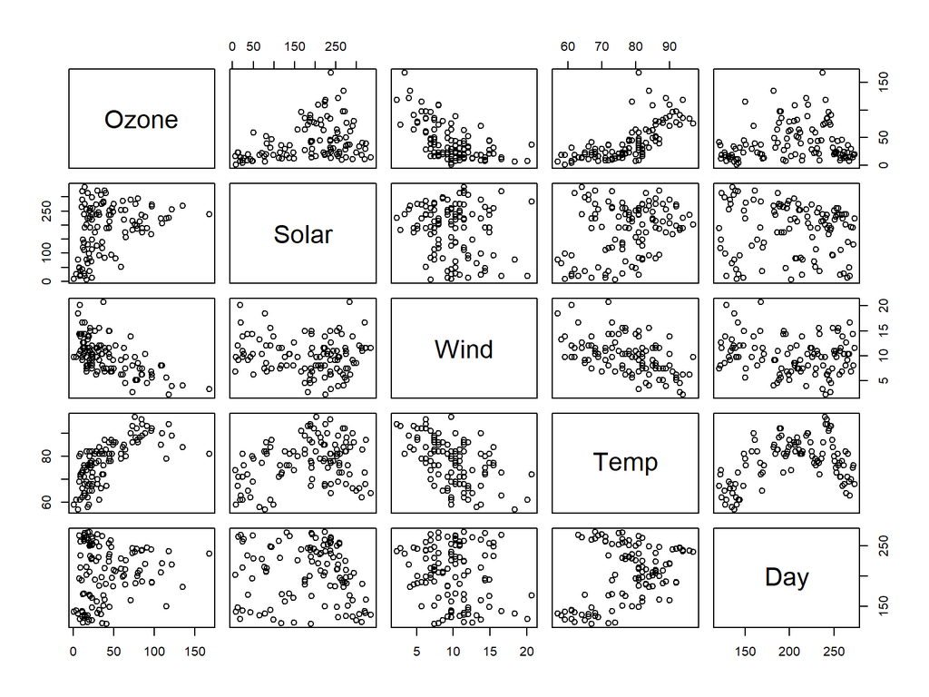

```r
pairs(ozone)
```

- These data are interesting in that many of the candidate predictors are correlated with each other
- We also see that `Ozone` is right-skewed with possible outliers
- Finally, some relationships (like those involving `Solar` and `Ozone`) might be non-linear

## Modeling Ozone Concentrations

- Suppose we specify the model:
  $$\text{Ozone} = \beta_0 + \beta_1\text{Solar} + \beta_2\text{Wind} + \beta_3\text{Temp} + \beta_4\text{Day} + \epsilon$$
- We’ve discussed two methods of fitting (training) this model:

```
##
## Call:
## lm(formula = Ozone ~ ., data = ozone)
##
## Coefficients:
## (Intercept)        Solar         Wind         Temp          Day
##   -59.98323      0.05107     -3.31806      1.82684     -0.08086
```

```
## 5 x 1 sparse Matrix of class "dgCMatrix"
##                       1
## (Intercept) -59.6708940
## Solar         0.0499358
## Wind         -3.2765343
## Temp          1.8013415
## Day          -0.0736570
```

## Cross-validation

- Cross-validation provides us a way of objectively evaluating the *out-of-sample performance* of each of these fitted models:

```
##
## Call:
## summary.resamples(object = rs)
##
## Models: LM, LASSO
## Number of resamples: 50
##
## MAE
##           Min.  1st Qu.   Median     Mean  3rd Qu.     Max. NA's
## LM    10.33020 14.45408 16.05873 16.02286 17.58568 21.96822    0
## LASSO 10.40927 14.50655 16.03768 16.01881 17.60856 21.99428    0
##
## RMSE
##           Min.  1st Qu.   Median     Mean  3rd Qu.     Max. NA's
## LM    13.05096 18.34489 20.38558 21.25087 23.19830 32.14463    0
## LASSO 13.06824 18.19826 20.29736 21.23866 23.36945 32.30306    0
##
## Rsquared
##            Min.   1st Qu.    Median      Mean   3rd Qu.      Max. NA's
## LM    0.4389994 0.5663953 0.6363050 0.6337505 0.7051311 0.8285290    0
## LASSO 0.4390296 0.5666160 0.6354906 0.6330466 0.7026281 0.8267978    0
```

- These results slightly favor the LASSO model, but what if the parametric form of these models was a poor choice?

## Generalized Additive Models

- Modeling is inherently a trade-off between model flexibility (the ability to capture patterns in the data) and overfitting (the propensity to detect non-existent patterns in noisy data)
- LASSO is a useful method for preventing overfitting, but it is a relatively inflexible model
- **Generalized additive models** are more flexible variant of the linear regression model:
  $$f(\mathbf{X}) = \beta_0 + s_1(X_{1}) + s_2(X_2) + \ldots + s_p(X_p) + \epsilon$$
- Here $s_j$ is a smooth function of variable $j$ that allows the model to capture *non-linear effects*
  - We’ll typically take $s_j$ to be a spline function

## Generalized Additive Models

- Below is was the generalized additive model looks like for the ozone modeling application:

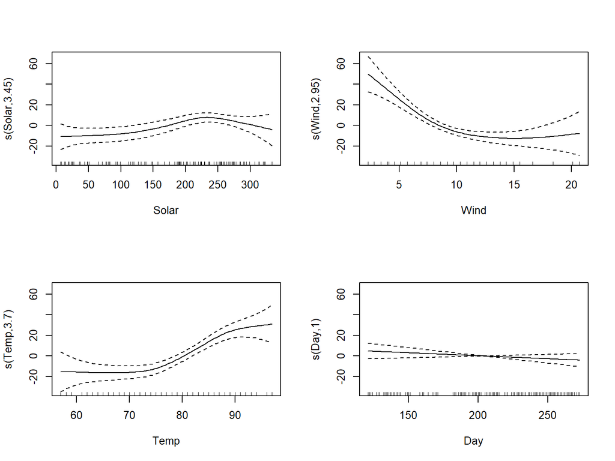

```r
library(mgcv)
fit.gam <- gam(Ozone ~ s(Solar) + s(Wind) + s(Temp) + s(Day), data = ozone)

par(mfrow = c(2,2))
plot(fit.gam)
```

- Notice how the spline functions more flexibility represent the relationship between predictors and ozone

## Generalized Additive Models

- Does the GAM model’s added flexibility lead to better predictions? cross-validation can answer this question!

```
##
## Call:
## summary.resamples(object = rs)
##
## Models: LM, LASSO, GAM
## Number of resamples: 50
##
## MAE
##            Min.  1st Qu.   Median     Mean  3rd Qu.     Max. NA's
## LM    10.330202 14.45408 16.05873 16.02286 17.58568 21.96822    0
## LASSO 10.409265 14.50655 16.03768 16.01881 17.60856 21.99428    0
## GAM    9.545238 13.32255 14.43085 14.59268 15.89816 22.06478    0
##
## RMSE
##           Min.  1st Qu.   Median     Mean  3rd Qu.     Max. NA's
## LM    13.05096 18.34489 20.38558 21.25087 23.19830 32.14463    0
## LASSO 13.06824 18.19826 20.29736 21.23866 23.36945 32.30306    0
## GAM   11.61305 16.79440 18.93730 20.12179 22.70400 39.99114    0
##
## Rsquared
##            Min.   1st Qu.    Median      Mean   3rd Qu.      Max. NA's
## LM    0.4389994 0.5663953 0.6363050 0.6337505 0.7051311 0.8285290    0
## LASSO 0.4390296 0.5666160 0.6354906 0.6330466 0.7026281 0.8267978    0
## GAM   0.1352313 0.6277171 0.6955973 0.6757420 0.7465107 0.8952280    0
```

- The answer is yes! As we might have expected from our EDA, some predictors have non-linear relationships with ozone concentrations

## Feature Selection

- The last aspect of modeling we’ve yet to cover is feature selection
- This is a large area of modeling (too large for us to fully explore); however, cross-validation provides a tool for comparing models with and without features:

```r
set.seed(123)
fit3 <-train(Ozone ~ ., data = ozone, method = "gam", trControl = fit.control)

set.seed(123)
fit4 <-train(Ozone ~ ., data = ozone[,-5], method = "gam", trControl = fit.control)

rs <- resamples(list(GAM = fit3, GAM_noDay = fit4))
summary(rs)
```

```
##
## Call:
## summary.resamples(object = rs)
##
## Models: GAM, GAM_noDay
## Number of resamples: 50
##
## MAE
##               Min.  1st Qu.   Median     Mean  3rd Qu.     Max. NA's
## GAM       9.545238 13.32255 14.43085 14.59268 15.89816 22.06478    0
## GAM_noDay 8.826571 12.54448 13.82750 14.06505 15.32965 21.20232    0
##
## RMSE
##               Min.  1st Qu.   Median     Mean  3rd Qu.     Max. NA's
## GAM       11.61305 16.79440 18.93730 20.12179 22.70400 39.99114    0
## GAM_noDay 11.34324 15.87775 18.48522 19.54451 22.34528 39.00616    0
##
## Rsquared
##                Min.   1st Qu.    Median      Mean   3rd Qu.      Max. NA's
## GAM       0.1352313 0.6277171 0.6955973 0.6757420 0.7465107 0.8952280    0
## GAM_noDay 0.2058017 0.6447336 0.7153919 0.6936967 0.7702964 0.8821372    0
```

- EDA seemed to suggest that `Day` wasn’t very strongly related to Ozone, particularly if you consider the relationship between `Day` and other predictors
- Cross-validation confirms that removing this variable leads to a better model (likely by reducing overfitting)

## Conclusion

- Effective modeling tends to be a cyclic process:
  - Begin with exploratory data analysis
  - Try some simple models (evaluating their performance objectively using cross-validation)
  - Slowly add complexity: variable transformations, adding/dropping variables, non-linear effects
  - Re-evaluate these new models using cross-validation
  - Repeat until an acceptable model is found